# Module 10: Creating a Graphical User Interface with Google Earth Engine

Developed by the Graduate Degree Program in Ecology and the Natural Resource Ecology Laboratory at CSU Authors: Dan Carver, Peder Engelstad

Updated September, 2019

# 1 Introduction

In this module, we will discuss the following concepts:

1. The GEE objects used in generating a graphical user interface.
2. How to develop panels with interactive elements.
3. How to connect geoprocessing elements to interactive elements.

# 2 Background

Over the past ten modules we have shown that Google Earth Engine can be a significant and efficient resource for visualizing and running analyses with remotely sensed data. Given the range of topics addressed over these modules it is also clear that many different fields of science and management can benefit from the application of remotely sensed data. That said, being comfortable enough to engage with GEE and create your own scientifically sound analysis is something that not everyone will have the time or energy to do. More often than not, project partners are not going to be excited if the final deliverable they receive is simply a bunch of code. In this module we will cover the process of creating a Graphical User Interface (GUI) that will allow a more straightforward, point-and-click experience of the geoprocessing that the code is performing.

## 2.1 About the Data

# 3 Understanding the Graphical User Interface

The Google Earth Engine Code Editor is a graphical user interface on its own. While we cannot alter the base elements (map, task pane, etc.), we can add to their functionality. Depending on the need, one can add three different classes of elements (widgets, panels, and events) to the existing GUI. These three class elements are interconnected. To learn a bit more about each element we will use an example where we ask a simple question about the capabilities of a Landsat image.

> Using NDVI derived from Landsat can we effectively distinguish the “A” on the hogback just west of Fort Collins from the surrounding vegetation in the summer?*

We will begin with simplified examples to provide a conceptual understanding of how the elements of GUI development work in GEE. Once we cover these elements we will move on to a more complex presentation of this material by reproducing the River Morphology Evaluation Toolbox (RMET) code to map the vegetation change of river deltas across the Landsat 5-8 collection timeframe (1984 to present).

## 3.1 Widgets

**Widgets** are the base level functions for adding interactivity to your code. There are many widgets available to choose from. Before continuing this module, we highly suggest visiting the [documentation](https://developers.google.com/earth-engine/ui_widgets) for widgets and running through all the presented examples by copying and pasting the code examples into a GEE script.

To demonstrate a widget, we are going to generate a histogram of values from the region surrounding the “A” in the image below to see if there is a bimodal pattern to the distribution due to the white color of the “A”.

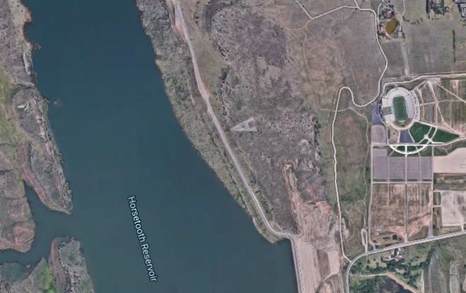

*A high resolution, less than one meter, image of the hillslope on the outskirts of Fort Collins, CO that has a large white A painted on it each year.*

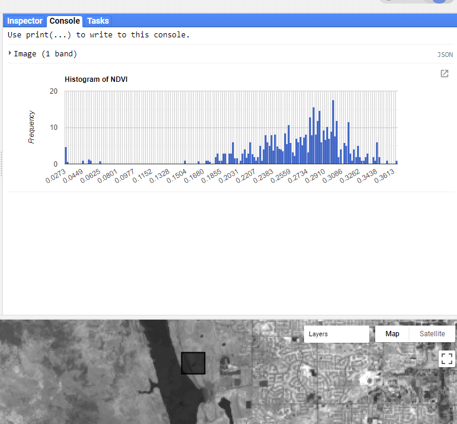

```javascript
// Load and display an NDVI image.
var ndvi = ee.ImageCollection('LANDSAT/LC8_L1T_8DAY_NDVI')
    .filterDate('2015-04-01', '2015-10-01')
    .median();
print(ndvi);
Map.addLayer(ndvi, {min:-0.1, max:0.6},'median NDVI ');
Map.setCenter(-105.147578,40.5593, 13); // Center on the Big A.

// Define a geometry feature that encompasses the "A".
var geometry = ee.Geometry.Polygon([[-105.154316,40.5593]
,[-105.147578,40.5593]
,[-105.147578,40.5640]
,[-105.154316,40.5640]
,[-105.154316,40.5593]]);
Map.addLayer(geometry, {}, 'geometry');

// Use the UI histogram function to produce a histogram of all values within the geometry feature.
var histo = ui.Chart.image.histogram({image:ndvi,region:geometry, scale:30});
print(histo);
```

*A histogram of NDVI values within the black square geometry feature that encompasses the A.*

The end result of our script is a histogram printed in the console tab. You can alter the geometry object’s area and the date range of the imagery to further refine the data and potentially get at the answer to our question. As the data are presented now it appears that the “A” is neither large enough or white enough to be easily differentiated from the surrounding landscape. The small peak in value at the very low end of the distribution is due to the water.

## 3.2 Panels

**Panels and Layouts** are used to generate containers at different places in the map, which can be used to hold specific widgets. If no panels are specified, most widgets appear in the console, as shown in the previous example. By applying panels, you can create a layout that emphasizes the use of the map and not the code. Look at the example from the RMET tool below.

[figure not shown]

*The RMET tool uses a panel to hold multiple widgets that allow the user to ask questions without engaging with the code.*

The end user need only to hit the run button. Then, all the elements they need to engage with the code will be presented and described on the panel. They can effectively ignore the code and console and focus on the map. To learn more, we suggest reviewing the [documentation](https://developers.google.com/earth-engine/ui_panels) of panels and layouts to learn more.

As we mentioned above, printing elements to the console is great for individuals who are using the code editor. But for individuals who will not be editing the code, it is best to place the elements of interest on the map. In the script below, we create a panel to store text about what we are showing and hold our histogram for more convenient viewing. Copy this code into your code editor and run it to view the changes.

```javascript
// Create a second histogram
var histo2 = ui.Chart.image.histogram({image:ndvi,region:geometry, scale:30});

// Create an empty panel in which to arrange widgets.
// The layout is vertical flow by default.
var panel = ui.Panel({style: {width: '400px'}})
     .add(ui.Label('We are attempting to differentiate the "A" from the surrounding landscape using NDVI values from Landsat Imagery. The histogram shows a distribution of all NDVI values found within the "geometry" layer on the map.'))
     .add(histo2);
ui.root.add(panel);
```

While panels do not have much to offer in terms of analytical processes they are great resource for organization.

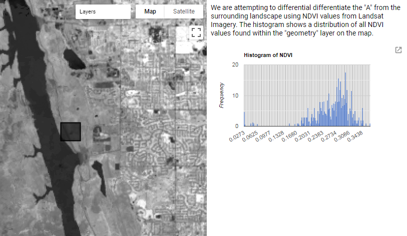

*A histogram of NDVI values within the black square geometry features added to a panel on the map.*

We can see that the information in the histogram has not changed, it is just presented in a different location.

## 3.3 Events

**Events** are triggers that perform a predefined action once selected by the user and are associated with widgets or map functions. The example below incorporates a widget, panel, and event. The panel is used to display the result of the event. In this case the mean NDVI at a user selected location. More information about events can be found in the [Events Documentation.](https://developers.google.com/earth-engine/ui_events)

```javascript
// Load and display an NDVI image.
var ls = ee.ImageCollection('LANDSAT/LC8_L1T_8DAY_NDVI')
    .filterDate('2015-04-01', '2015-10-01');
var vis = {min: 0, max: 1, palette: ['99c199', '006400']};
Map.addLayer(ls.median(), vis, 'NDVI');


// Configure the map.
Map.style().set('cursor', 'crosshair');

// Create a panel and add it to the map.
var inspector = ui.Panel([ui.Label('Click to get max NDVI')]);
Map.add(inspector);

Map.onClick(function(coords) {
  // Show the loading label.
  inspector.widgets().set(0, ui.Label({
    value: 'Loading...',
    style: {color: 'gray'}
  }));

  // Determine the mean NDVI, a server operation.
  var point = ee.Geometry.Point(coords.lon, coords.lat);
  var meanNdvi = ls.reduce('mean');
  var sample = meanNdvi.sample(point, 30);
  var computedValue = sample.first().get('NDVI_mean');

  // Request the value from the server.
  computedValue.evaluate(function(result) {
    // When the server returns the value, show it.
    inspector.widgets().set(0, ui.Label({
      value: 'Mean NDVI: ' + result.toFixed(2),
    }));
  });
});
```

When the user clicks on a location on the map, the `Map.onClick()` event passes coordinates into the function. This will then run the remaining elements of the function. The first widget `inspector.widgets()` is used to acknowledge that the users input, through clicking, was received. The loading message should help stop the user from continuously clicking and thereby prevent them from restarting the event process. Once the underlying geoprocessing code has returned a value, the `inspector.widgets()` is used again to replace the “loading” statement with the value the user requested.

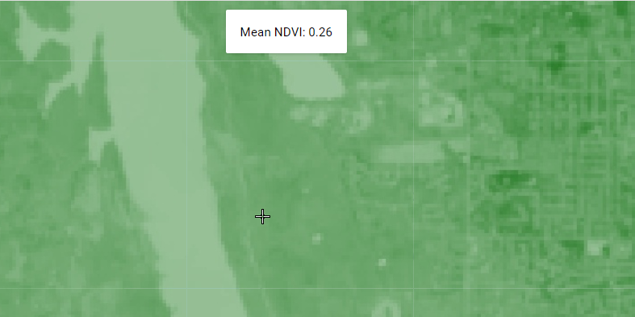

*When the user clicks on locations of interest, the `on.Click()` event function will return the mean NDVI value for the location.*

The geoprocessing is taking place within a function which means the variables within the function (`point`, `meanNDVI`, `sample`, etc.) only exist within that function. You can test this by attempting to print the `computedValue` variable.

```javascript
print(computedValue);
```

This will return the warning message `"computedValue is not defined in this scope."` What this means is that the variable is not defined in the local environment, so GEE does not have any information to print. This can get confusing but is an important element to understand when working with GUI development.

## 3.4 Tying it all Together

As these examples have shown, the development of a GUI in GEE can quickly become a complex process. In order to work efficiently with GUI development, it is important to have a solid understanding of Functions and Client vs. Server side environments. More detail on both these topics can be found in the [online documentation.](https://developers.google.com/earth-engine/client_server);

**Client Side Objects** are native JavaScript elements that exist in the local environment.

**Server Side Objects** are JavaScript wrappers that are used to communication information to the functions that we never see on Google’s Servers.

To illustrate this let us look at a previous code chuck for defining the area of interest. *Note: You do not need to run this section of code*

```javascript
// Define a geometry feature that encompasses the "A".
var geometry = ee.Geometry.Polygon([[-105.154316,40.5593]
,[-105.147578,40.5593]
,[-105.147578,40.5640]
,[-105.154316,40.5640]
,[-105.154316,40.5593]]);
Map.addLayer(geometry, {}, 'geometry');
```

The numerical values of the coordinates and the string ‘geometry’ text and even the `Map.addLayer` function are all client side objects. When we call `ee` functions we are creating elements that need to communicate with the server to work as we expect them to. In this example, `ee.Geometry.Polygon` is a server side object. The server side objects do not mean anything in JavaScript themselves. They are used as references, basically a set of instructions for what the servers that run GEE should do within this request.

For example, this text is a JavaScript string (“aString”). Yet, if you tried to call the `ee.String()` function `length()` on this JavaScript string you would get an error “*JavaScriptString*.length is not a function”. You would need to change your client side string “aString” to a server side string object by calling `ee.String("aString")` before you could apply any of the `ee.String` functions.